# Projekt - Wprowadzenie do ML

Autorzy

Anna Kaczmarek

Piotr Mariusz Kozikowski

Kacper Dulewicz

[figure not shown]

Celem projektu jest bazując na zbiorze danych dotyczącym Pokemonów budowa modeli regresyjnych przewidujących punkty życia Pokemona na podstawie pozostałych parametrów.

Zbiór `pokemons` zawiera spis pokemonów oraz ich dodatkowe paramatery i atrybuty takie jak:

- `Class` - typ/rodzaj ataku pokemona
- `HP` - punkty życia
- `Attack` - siła ataku
- `Defense` - siła obrony
- `Sp. Atk` - siła specjalnego ataku
- `Sp. Def` - siła specjalnej obrony
- `Speed` - prędkość

Poniżej wyświetlonych jest pięć pierwszych wierszy zbioru

**Pokaż kod**

```r
library(tidyverse)
library(kableExtra)
library(dplyr)
library(car)
library(corrplot)
library(glmnet)
library(caret)
library(gridExtra)
library(ggplot2)
library(ggcorrplot)
```

**Pokaż kod**

```r
pokemon_data <- read.csv("C:/Users/annak/OneDrive/Pulpit/MATEMATYKA STOSOWANA/II SEMESTR/WPROWADZENIE DO UCZENIA MASZYNOWEGO/pokemon_clean.csv", header = TRUE)
kbl(head(pokemon_data)) |>
  kable_styling(bootstrap_options = c("striped", "hover"))
```

| X | class | hp | attack | defense | sp_attack | sp_defense | speed | num_class |
| --- | --- | --- | --- | --- | --- | --- | --- | --- |
| 0 | Grass | 45 | 49 | 49 | 65 | 65 | 45 | 1 |
| 1 | Grass | 60 | 62 | 63 | 80 | 80 | 60 | 1 |
| 2 | Grass | 80 | 82 | 83 | 100 | 100 | 80 | 1 |
| 3 | Grass | 80 | 100 | 123 | 122 | 120 | 80 | 1 |
| 4 | Grass | 80 | 82 | 83 | 100 | 100 | 80 | 1 |
| 5 | Fire | 39 | 52 | 43 | 60 | 50 | 65 | 2 |

**Pokaż kod**

```r
#str(pokemon_data)
#summary(pokemon_data)
#any(is.na(pokemon_data)) - brak braków danych
```

# Podstawowe statystyki

Zobaczmy jak prezentują się podstawowe statystyki naszego zbioru, możemy zobaczyć zmienne takie jak min, max, średnią. Dzięki niej możemy lepiej zrozumieć nasze dane np.

**Pokaż kod**

```r
df <- pokemon_data
df_numeric <- df |>
  select_if(is.numeric)
df_numeric <- df_numeric[, -c(1, ncol(df_numeric))]

st_op <- apply(df_numeric, 2, summary)
st_op <- rbind(st_op, St.dev = apply(df_numeric, 2, sd))
st_op <- as.data.frame(round(st_op, 2))

kbl(st_op, caption = "<center><strong>PODSTAWOWE STATYSTYKI OPISOWE</strong></center>") |>
  kable_styling(bootstrap_options = c("striped", "hover"))
```

**PODSTAWOWE STATYSTYKI OPISOWE**

|  | hp | attack | defense | sp_attack | sp_defense | speed |
| --- | --- | --- | --- | --- | --- | --- |
| Min. | 1.00 | 5.00 | 5.00 | 10.00 | 20.00 | 5.00 |
| 1st Qu. | 50.00 | 56.00 | 52.00 | 50.00 | 50.00 | 45.00 |
| Median | 68.00 | 80.00 | 70.00 | 65.00 | 70.00 | 65.00 |
| Mean | 70.49 | 80.94 | 74.97 | 73.27 | 72.48 | 68.79 |
| 3rd Qu. | 84.00 | 100.00 | 90.00 | 95.00 | 90.00 | 90.00 |
| Max. | 255.00 | 190.00 | 250.00 | 194.00 | 250.00 | 200.00 |
| St.dev | 26.87 | 32.46 | 31.21 | 32.64 | 27.93 | 30.08 |

Analiza podstawowych statystyk opisowych ujawniła, że zmienna ‘hp’ (punkty życia) ma średnią wartość wynoszącą około 70.49, a jej rozkład jest nieco asymetryczny, z medianą wynoszącą 68.00, co wskazuje na lekką skośność rozkładu w prawo. Widzimy też, że wartość minimalna to 1, a maksymalna to 255, co wskazuje na sporą rozpiętość ‘hp’ w populacji. Odchylenie standardowe ‘hp’ wynosi około 26.87.

Zmienne ‘attack’, ‘defense’, ‘sp_attack’, ‘sp_defense’ i ‘speed’ mają zbliżone średnie, mieszczące się w przedziale od 68.79 do 80.94. Zmienne te również mają sporą rozpiętość, co sugeruje różnice między poszczególnymi pokemonami. Odchylenia standardowe w ich przypadku mieszczą się w przedziale od 27.93 do 32.64, co sugeruje porównywalne rozproszenie wokół średnich.

# Rozkład zmiennej zależnej

**Pokaż kod**

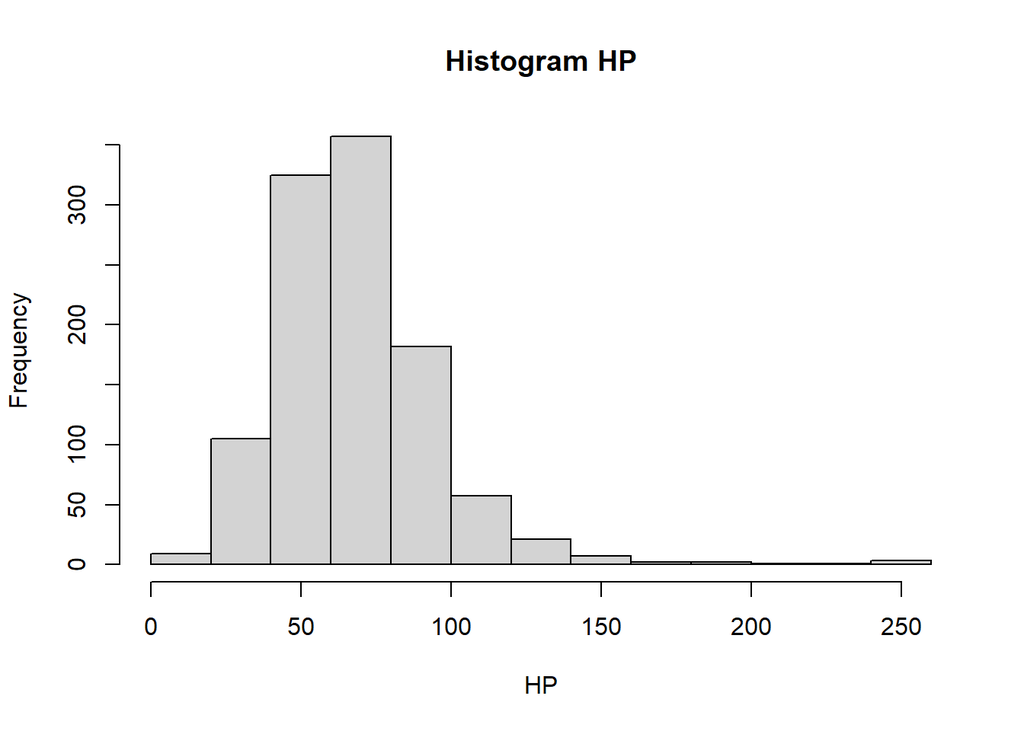

```r
hist(pokemon_data$hp, main = "Histogram HP", xlab = "HP")
```

**Pokaż kod**

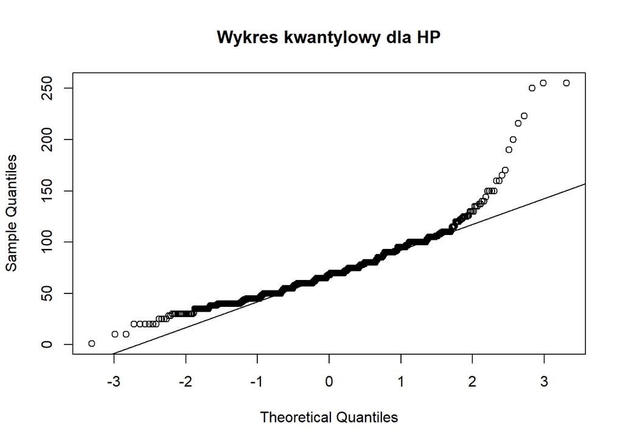

```r
qqnorm(pokemon_data$hp, main = "Wykres kwantylowy dla HP")
qqline(pokemon_data$hp)
```

# Przygotowanie danych do modelowania

**Pokaż kod**

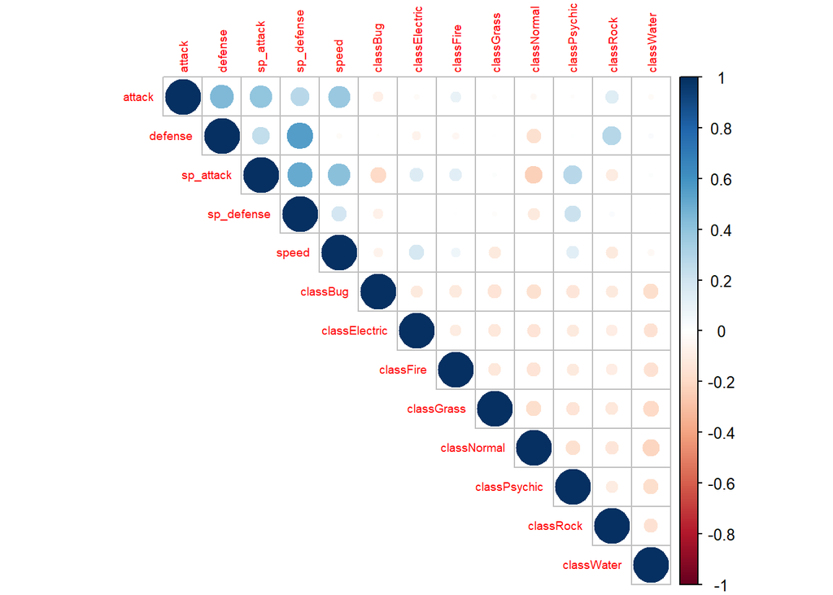

```r
class_counts <- table(pokemon_data$class)
threshold <- 50 # klasy z mniej niż 50 pokemonami zostaną pominięte i nie będzie dla nich utworzonej zmiennej dummy
selected_classes <- names(class_counts[class_counts >= threshold])
pokemon_data_filtered <- pokemon_data |>
  filter(class %in% selected_classes)

# Utworzenie zmiennych sztucznych "dummy" (zero-jedynkowych) z kolumny "class"
dummy_variables <- model.matrix(~ class - 1, data = pokemon_data_filtered)

dependent_variable <- pokemon_data_filtered$hp #Wyodrębnienie zmiennej zależnej

#  Wyodrębnienie zmiennych niezależnych
independent_variables_numeric <- pokemon_data_filtered |>
  select_if(is.numeric)
independent_variables_numeric <- independent_variables_numeric[, -c(1, ncol(independent_variables_numeric))]
independent_variables_numeric <- independent_variables_numeric[, -which(names(independent_variables_numeric) == "hp")]

independent_variables <- cbind(independent_variables_numeric, dummy_variables)

# Korelacja
cor_matrix <- cor(independent_variables)

# Macierz korelacji - heatmapa
corrplot(cor_matrix, method = "circle", type = "upper", tl.cex = 0.6)
```

Heatmapa korelacji przedstawia wizualizację zależności między zmiennymi niezależnymi, zarówno numerycznymi, jak i zmiennymi sztucznymi - dummy. W zmiennych numerycznych na heatmapie można zaobserwować kilka istotnych trendów:

- Silne, dodatnie korelacje między zmiennymi attack, sp_attack, defense i sp_defense są wyraźnie widoczne. To sugeruje, że Pokemony z wyższymi wartościami jednej z tych statystyk, mają tendencję do posiadania wyższych wartości również pozostałych
- Zmienna speed jest słabo skorelowana z innymi zmiennymi
- Korelacje między defense i attack oraz sp_defense i sp_attack są trochę mniejsze od tych między atakiem i sp_attack oraz obroną i sp_defense, co może sugerować, że obrona fizyczna i specjalna są nieco bardziej niezależne.

Jeżeli chodzi o zmienne dummy widoczny jest brak silnych korelacji między nimi, co jest oczekiwane, ponieważ dany pokemon należy tylko do jednej klasy, a zmienne te tworzą zmienne wzajemnie wykluczające się.

Korelacje między zmiennymi numerycznymi a zmiennymi sztucznymi są na ogół słabe i nie wykazują istotnych trendów.

## Podział danych na zbiór treningowy i testowy

W celu oceny zdolności generalizacji modeli, dane zostały podzielone na dwa rozłączne zbiory: zbiór treningowy (80% danych) i zbiór testowy (20% danych). Podziału dokonano z użyciem funkcji createDataPartition z pakietu caret, która zapewnia losowy, ale powtarzalny podział danych.

**Pokaż kod**

```r
set.seed(2137)  # setseed dla powtarzalności
train_index <- createDataPartition(dependent_variable, p = 0.8, list = FALSE)
train_data <- as.matrix(independent_variables[train_index, ])
train_labels <- dependent_variable[train_index]
test_data <- as.matrix(independent_variables[-train_index, ])
test_labels <- dependent_variable[-train_index]
```

# Regresja Wieloraka

W celu uniknięcia problemu współliniowości, wynikającego z zależności liniowej między zmiennymi dummy i wyrazem wolnym w modelu regresji, zdecydowano się na usunięcie jednej z kolumn zmiennych dummy. Pomimo iż nie tworzono sztucznych zmiennych dla wszystkich klas, sama konstrukcja zmiennych zero-jedynkowych powoduje, że suma ich dla każdej obserwacji wynosi 1. Usuwając jedną kolumnę, zlikwidowano tę zależność, umożliwiając prawidłowe oszacowanie współczynników modelu i obliczenie wskaźnika VIF.

Usunięta kategoria ‘class’ staje się kategorią referencyjną dla pozostałych zmiennych dummy.

**Pokaż kod**

```r
independent_variables_no_alias <- as.data.frame(independent_variables[, -which(colnames(independent_variables) %in% colnames(dummy_variables)[7])])
```

## Model

**Pokaż kod**

```r
model <- lm(dependent_variable ~ ., data = independent_variables_no_alias)
summary(model)
```

```
Call:
lm(formula = dependent_variable ~ ., data = independent_variables_no_alias)

Residuals:
    Min      1Q  Median      3Q     Max
-68.940 -11.657  -2.828   8.292 175.250

Coefficients:
              Estimate Std. Error t value Pr(>|t|)
(Intercept)   27.13453    4.30449   6.304 5.19e-10 ***
attack         0.25879    0.03246   7.973 6.48e-15 ***
defense       -0.08702    0.03915  -2.223  0.02657 *
sp_attack      0.13864    0.03436   4.035 6.08e-05 ***
sp_defense     0.29534    0.04061   7.272 9.65e-13 ***
speed         -0.09034    0.03174  -2.846  0.00455 **
classBug      -3.52457    3.71679  -0.948  0.34332
classElectric -4.25029    4.16054  -1.022  0.30734
classFire      0.01726    4.00881   0.004  0.99656
classGrass     1.42086    3.66101   0.388  0.69806
classNormal   15.41048    3.59323   4.289 2.05e-05 ***
classPsychic   0.12421    4.01773   0.031  0.97535
classWater     5.31657    3.45269   1.540  0.12406
---
Signif. codes:  0 '***' 0.001 '**' 0.01 '*' 0.05 '.' 0.1 ' ' 1

Residual standard error: 21.26 on 688 degrees of freedom
Multiple R-squared:  0.3256,    Adjusted R-squared:  0.3138
F-statistic: 27.68 on 12 and 688 DF,  p-value: < 2.2e-16
```

Model regresji wielorakiej wskazuje, że statystyki pokemonów takie jak ‘attack’, ‘sp_attack’ i ‘sp_defense’ mają istotny, pozytywny wpływ na ‘HP’, natomiast ‘defense’ i ‘speed’ mają istotny, negatywny wpływ. Przynależność do klasy ‘Normal’ również okazała się istotnym predyktorem, wskazując na wyższe ‘HP’ w porównaniu z kategorią referencyjną. Pozostałe klasy Pokemonów, nie wykazały istotnego wpływu po uwzględnieniu statystyk podstawowych.

Model wyjaśnia około 31% wariancji ‘HP’, a standardowy błąd resztowy wynosi 21.26, co sugeruje, że model jest dobry, ale nie idealny. Analiza modelu potwierdziła statystyczną istotność zależności, jednak widać, że sam model nie wyjaśnia całej zmienności w wartości ‘HP’.

## Diagnostyka modelu

### VIF

**Pokaż kod**

```r
# VIF
vif_values <- vif(model)
vif_df <- data.frame(
  Variable = names(vif_values),
  VIF = vif_values
)
kbl(vif_df, caption = "<center><strong>Wskaźniki VIF (Variance Inflation Factor)</strong></center>", row.names = F)  |>
  column_spec(1, bold = TRUE) |>
    kable_styling(
        bootstrap_options = c("striped", "hover", "condensed", "responsive"),
        full_width = F,
        position = "center"
        )
```

**Wskaźniki VIF (Variance Inflation Factor)**

| Variable | VIF |
| --- | --- |
| attack | 1.706895 |
| defense | 2.058709 |
| sp_attack | 1.979113 |
| sp_defense | 1.940881 |
| speed | 1.465282 |
| classBug | 2.237188 |
| classElectric | 2.196648 |
| classFire | 2.155237 |
| classGrass | 2.436124 |
| classNormal | 2.785281 |
| classPsychic | 2.531888 |
| classWater | 2.892033 |

W modelu regresji wielorakiej nie występuje problem silnej współliniowości. Wszystkie wartości VIF dla zmiennych niezależnych są relatywnie niskie, nie przekraczając wartości 3. Zmienne numeryczne z zakresu statystyk pokemonów uzyskały VIF między 1.4 i 2.1. Wskaźniki VIF dla zmiennych dummy oscylują między 2.1 a 2.9.

Wartości VIF poniżej 5, a tym bardziej 10, sugerują brak poważnych problemów współliniowości, co oznacza, że model regresji liniowej może być z powodzeniem użyty w tym przypadku bez konieczności wykluczania zmiennych.

### Metryki

**Pokaż kod**

```r
predictions_lm <- predict(model, newdata = as.data.frame(test_data))

mse_lm <- mean((predictions_lm - test_labels)^2)
rmse_lm <- sqrt(mse_lm)
mae_lm <- mean(abs(predictions_lm - test_labels))
r2_lm <- 1 - (sum((predictions_lm - test_labels)^2) / sum((test_labels - mean(test_labels))^2))

metrics_lm <- data.frame(
    Metric = c("MSE", "RMSE", "MAE", "R-squared"),
    Value = c(mse_lm, rmse_lm, mae_lm, r2_lm)
)
kbl(metrics_lm, caption = "<center><strong>Metryki modelu regresji wielorakiej</strong></center>") |>
      column_spec(1, bold = TRUE) |>
      kable_styling(
        bootstrap_options = c("striped", "hover", "condensed", "responsive"),
        full_width = F,
        position = "center"
        )
```

**Metryki modelu regresji wielorakiej**

| Metric | Value |
| --- | --- |
| MSE | 394.1833977 |
| RMSE | 19.8540524 |
| MAE | 14.2971345 |
| R-squared | 0.3683939 |

### Analiza reszt (wykresy reszt vs. wartości dopasowane)

**Pokaż kod**

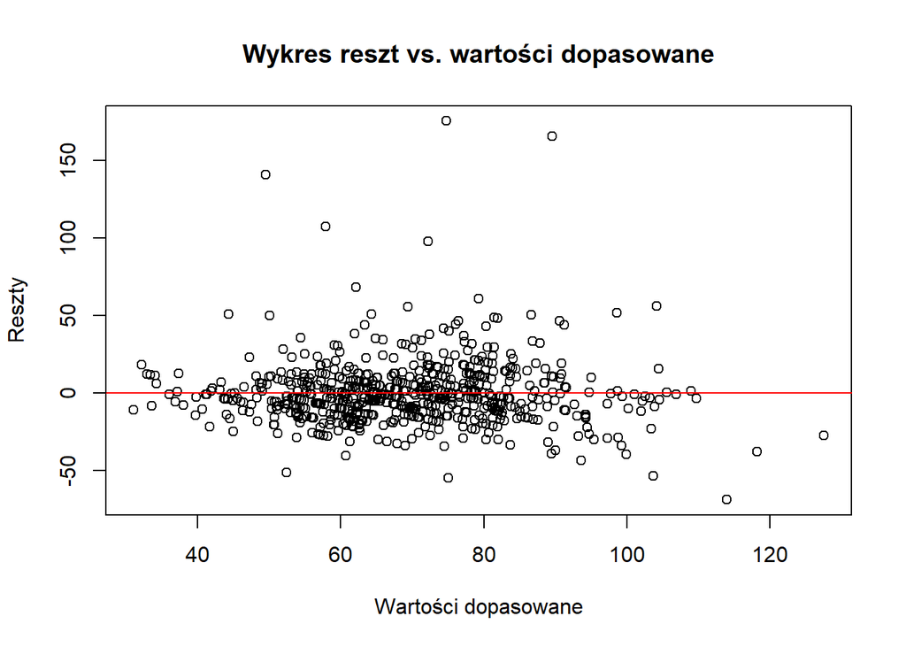

```r
# Analiza reszt (wykresy reszt vs. wartości dopasowane)
plot(model$fitted.values, model$residuals,
     xlab = "Wartości dopasowane", ylab = "Reszty",
     main = "Wykres reszt vs. wartości dopasowane")
abline(h = 0, col = "red")
```

### QQ-plot

**Pokaż kod**

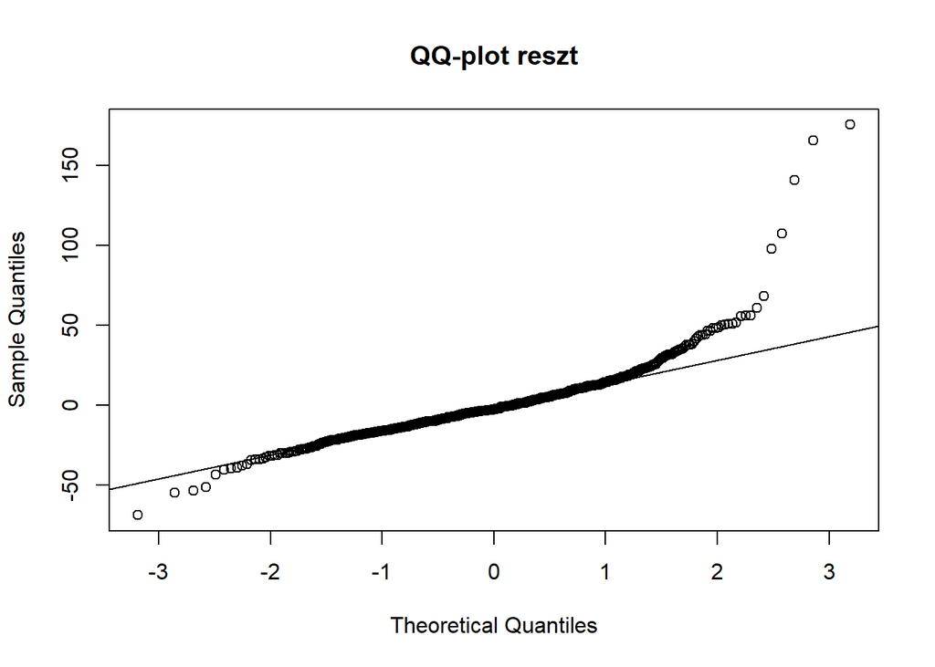

```r
# QQ-plot
qqnorm(model$residuals, main = "QQ-plot reszt")
qqline(model$residuals)
```

### Obserwacje odstające - odległość Cooka

**Pokaż kod**

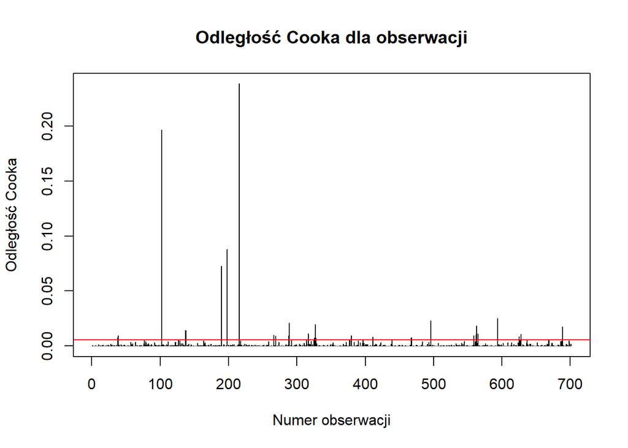

```r
cooks_dist <- cooks.distance(model)
plot(cooks_dist, type = "h",
     xlab = "Numer obserwacji", ylab = "Odległość Cooka",
     main = "Odległość Cooka dla obserwacji")
abline(h = 4/length(cooks_dist), col = "red") # Wartość progowa
```

**Pokaż kod**

```r
# Zidentyfikowanie obserwacji odstających
threshold <- 4/length(cooks_dist) # domyślny próg
high_outlier_threshold <- threshold * 2 # wyższy próg
outliers <- which(cooks_dist > high_outlier_threshold)

if(length(outliers)>0){
outliers_df <- data.frame(Outlier_Number = outliers)
kbl(outliers_df, caption = paste("<center><strong>Numery obserwacji odstających (odległość Cooka > ", round(high_outlier_threshold, 3), ")</strong></center>")) %>%
  column_spec(1, bold = TRUE) |>
      kable_styling(
        bootstrap_options = c("striped", "hover", "condensed", "responsive"),
        full_width = F,
        position = "center"
        )
  } else {
    print(paste("Nie znaleziono obserwacji odstających powyżej progu: ", round(high_outlier_threshold, 3) ))
  }
```

**Numery obserwacji odstających (odległość Cooka > 0.011 )**

|  | Outlier_Number |
| --- | --- |
| 102 | 102 |
| 137 | 137 |
| 138 | 138 |
| 190 | 190 |
| 198 | 198 |
| 216 | 216 |
| 289 | 289 |
| 327 | 327 |
| 496 | 496 |
| 563 | 563 |
| 594 | 594 |
| 689 | 689 |

Wykres odległości Cooka wskazuje, że kilka obserwacji wykazuje znacznie większe wartości odległości Cooka niż pozostałe. Obserwacje z odległością Cooka przekraczającą **dwukrotność progu (który został wyliczony jako 4 podzielone przez liczbę obserwacji)**, uznano za wartości odstające i zostały one przedstawione w poniższej tabeli. Zazwyczaj obserwacje o odległości Cooka większej niż 4/n (gdzie n to liczba obserwacji) są traktowane jako odstające i to też było naszym progiem, ale tutaj pokazujemy te, które mocno od niego odbiegają. Ich obecność należy wziąć pod uwagę przy interpretacji wyników regresji i ewentualnie zastanowić się nad ich usunięciem lub modyfikacją.

Pomimo drobnych niedoskonałości, model regresji wielorakiej wydaje się być ogólnie odpowiedni dla analizowanych danych, a dalsza analiza będzie kontynuowana poprzez sprawdzenie, czy inne metody regresji dadzą lepsze rezultaty.

# Regresja Lasso

## Siatka wartości parametru $\lambda$

**Pokaż kod**

```r
lambda_seq <- 10^seq(2, -2, by = -.1)
```

## Budowa modeli i wybór optymalnego $\lambda$ za pomocą walidacji krzyżowej

**Pokaż kod**

```r
cv_model <- cv.glmnet(train_data, train_labels, alpha = 1, lambda = lambda_seq, nfolds = 10)
best_lambda <- cv_model$lambda.min # minimalizujemy błąd walidacyjny
print(paste("Najlepsza wartość lambda:", best_lambda))
```

```
[1] "Najlepsza wartość lambda: 0.158489319246111"
```

**Pokaż kod**

```r
# Model dla optymalnego lambda
lasso_model_best <- glmnet(train_data, train_labels, alpha = 1, lambda = best_lambda)
# Model dla 10*lambda optymalne
lambda_larger = best_lambda*10
lasso_model_larger <- glmnet(train_data, train_labels, alpha = 1, lambda = lambda_larger)
```

## Analiza modeli

### Funkcja do oceny modelu

**Pokaż kod**

```r
evaluate_model <- function(model, lambda_value, test_data, test_labels, model_name) {
    predictions <- predict(model, s = lambda_value, newx = test_data) #predykcje dla podanego modelu na zbiorze testowym
    mse <- mean((predictions - test_labels)^2)
    rmse <- sqrt(mse)
    mae <- mean(abs(predictions - test_labels))
    r2 <- 1 - (sum((predictions - test_labels)^2) / sum((test_labels - mean(test_labels))^2))

    metrics <- data.frame(
        Metric = c("MSE", "RMSE", "MAE", "R-squared"),
        Value = c(mse, rmse, mae, r2)
    )

    coefs <- as.matrix(coef(model)) # współczynniki modelu
    coefs_df <- data.frame(
        Variable = rownames(coefs)[coefs != 0],
        Coefficient = as.numeric(coefs[coefs != 0])
    )

    output_list <- list()

    output_list$metrics_table <- kbl(metrics, caption = paste("<center><strong>Metryki modelu", model_name, "</strong></center>")) |> # wyświetlenie tabelą
        column_spec(1, bold = TRUE) |>
        kable_styling(
          bootstrap_options = c("striped", "hover", "condensed", "responsive"),
          full_width = F,
          position = "center"
          )

    output_list$coefs_table <- kbl(coefs_df, caption = paste("<center><strong>Współczynniki modelu", model_name, "</strong></center>")) |>
        column_spec(1, bold = TRUE) |>
        kable_styling(
          bootstrap_options = c("striped", "hover", "condensed", "responsive"),
          full_width = F,
          position = "center"
          )

    # wykres pred vs real
    prediction_plot <- ggplot(data.frame(test_labels = test_labels, predictions = as.numeric(predictions)), aes(x=test_labels, y=predictions)) +
      geom_point() +
      geom_abline(intercept = 0, slope = 1, color="red")+
      labs(title=paste("Predykcja vs. rzeczywiste dla ", model_name, " na zbiorze testowym"), x="Rzeczywiste HP", y="Przewidziane HP")
    output_list$prediction_plot <- prediction_plot

    return(output_list)
}
```

### Ocena modeli i wyświetlenie wyników

**Pokaż kod**

```r
output_best$metrics_table
```

**Metryki modelu Lasso - Optymalne Lambda**

| Metric | Value |
| --- | --- |
| MSE | 403.5353867 |
| RMSE | 20.0881902 |
| MAE | 14.5055681 |
| R-squared | 0.3534091 |

**Pokaż kod**

```r
output_best$coefs_table
```

**Współczynniki modelu Lasso - Optymalne Lambda**

| Variable | Coefficient |
| --- | --- |
| (Intercept) | 28.5849667 |
| attack | 0.2415415 |
| defense | -0.0870677 |
| sp_attack | 0.1116074 |
| sp_defense | 0.3130553 |
| speed | -0.0665870 |
| classBug | -5.9408478 |
| classElectric | -4.1080563 |
| classFire | -0.3421794 |
| classGrass | 0.8160057 |
| classNormal | 14.2027000 |
| classRock | -0.2893222 |
| classWater | 4.1990463 |

**Pokaż kod**

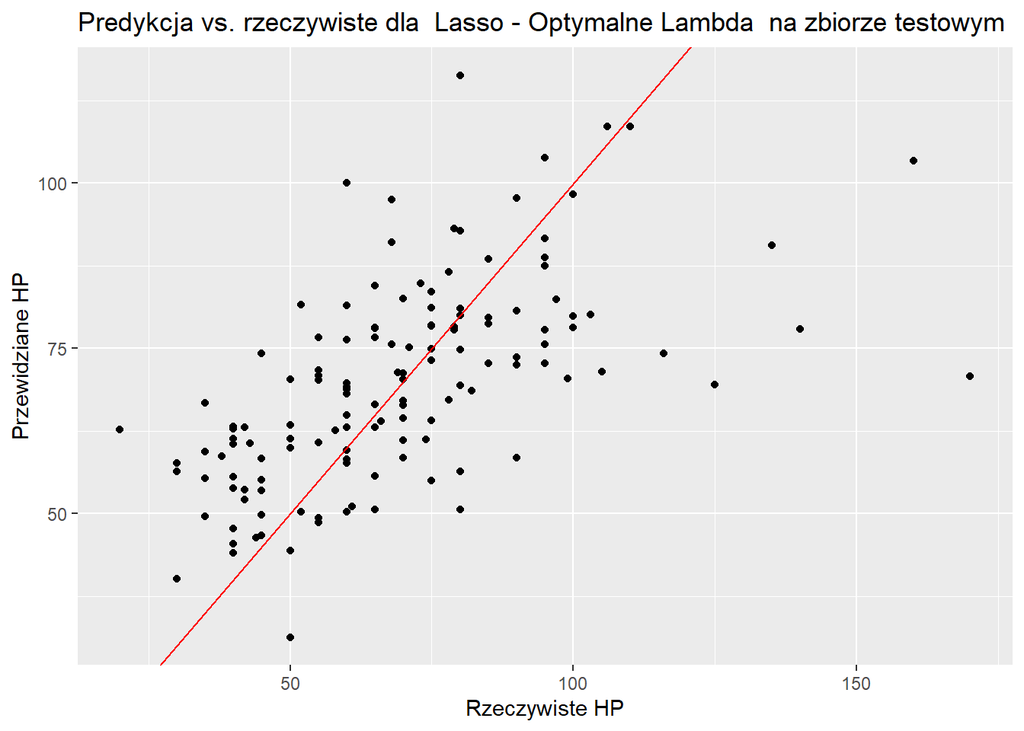

```r
output_best$prediction_plot
```

**Pokaż kod**

```r
output_larger$metrics_table
```

**Metryki modelu Lasso - Większe Lambda**

| Metric | Value |
| --- | --- |
| MSE | 420.3970811 |
| RMSE | 20.5035870 |
| MAE | 14.3387092 |
| R-squared | 0.3263913 |

**Pokaż kod**

```r
output_larger$coefs_table
```

**Współczynniki modelu Lasso - Większe Lambda**

| Variable | Coefficient |
| --- | --- |
| (Intercept) | 33.0401350 |
| attack | 0.1697500 |
| sp_attack | 0.0744704 |
| sp_defense | 0.2302413 |
| classBug | -4.2280470 |
| classElectric | -0.7391962 |
| classNormal | 9.2753334 |
| classWater | 0.0972844 |

**Pokaż kod**

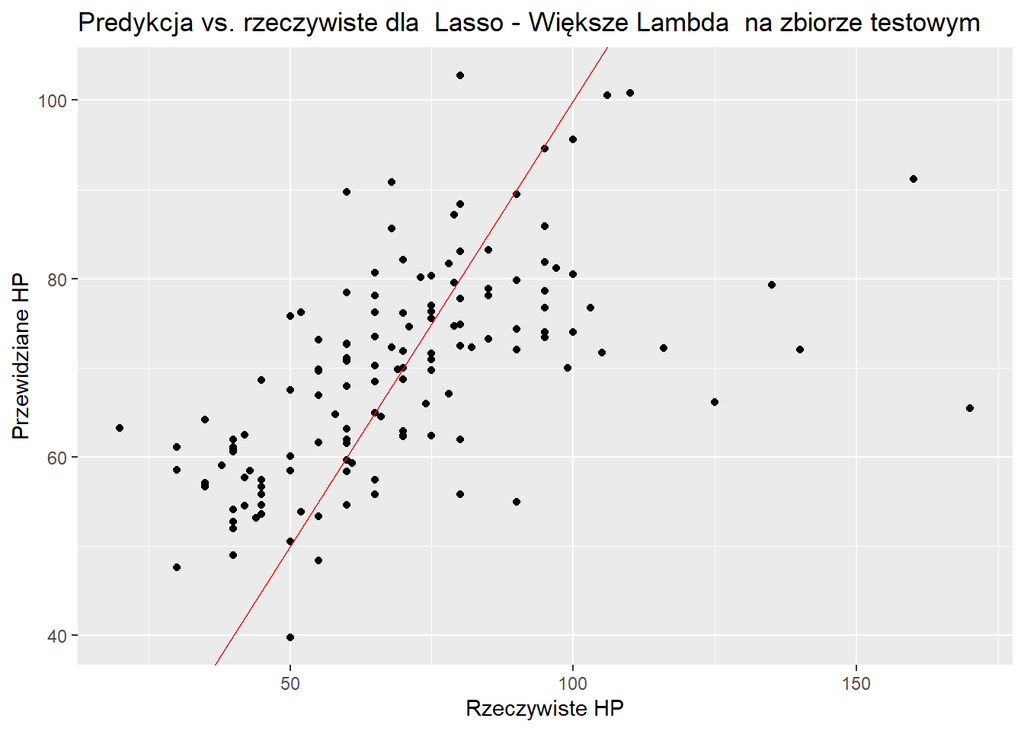

```r
output_larger$prediction_plot
```

### Porównanie modeli

**Pokaż kod**

```r
comparison_table <- data.frame(
    Model = c("Regresja Wieloraka", "Lasso - Optymalne Lambda", "Lasso - Większe Lambda"),
    MSE = c(mse_lm,
            mean((predict(lasso_model_best, s = best_lambda, newx = test_data) - test_labels)^2),
            mean((predict(lasso_model_larger, s = lambda_larger, newx = test_data) - test_labels)^2)),
    RMSE = c(rmse_lm,
            sqrt(mean((predict(lasso_model_best, s = best_lambda, newx = test_data) - test_labels)^2)),
            sqrt(mean((predict(lasso_model_larger, s = lambda_larger, newx = test_data) - test_labels)^2))),
    MAE = c(mae_lm,
            mean(abs(predict(lasso_model_best, s = best_lambda, newx = test_data) - test_labels)),
            mean(abs(predict(lasso_model_larger, s = lambda_larger, newx = test_data) - test_labels))),
    R_squared = c(r2_lm,
                1 - (sum((predict(lasso_model_best, s = best_lambda, newx = test_data) - test_labels)^2) / sum((test_labels - mean(test_labels))^2)),
             1 - (sum((predict(lasso_model_larger, s = lambda_larger, newx = test_data) - test_labels)^2) / sum((test_labels - mean(test_labels))^2)))
)

kbl(comparison_table, caption = "<center><strong>Porównanie metryk modeli</strong></center>") |>
        kable_styling(bootstrap_options = c("striped", "hover"))
```

**Porównanie metryk modeli**

| Model | MSE | RMSE | MAE | R_squared |
| --- | --- | --- | --- | --- |
| Regresja Wieloraka | 394.1834 | 19.85405 | 14.29713 | 0.3683939 |
| Lasso - Optymalne Lambda | 403.5354 | 20.08819 | 14.50557 | 0.3534091 |
| Lasso - Większe Lambda | 420.3971 | 20.50359 | 14.33871 | 0.3263913 |

Aby rzetelnie ocenić wydajność każdego modelu, wszystkie wyniki metryk (MSE, RMSE, MAE, R-kwadrat) zostały uzyskane na podstawie predykcji dokonanych na zbiorze testowym, który nie brał udziału w procesie trenowania modeli.

# Regresja grzbietowa

## Siatka wartości parametrów $\alpha$ i $\lambda$

**Pokaż kod**

```r
alpha_seq <- seq(0.1, 0.9, by = 0.2) # kilka wartości alpha miedzy 0 i 1
lambda_seq <- 10^seq(2, -2, by = -.1)
```

## Budowa modeli regresji grzbietowej

**Pokaż kod**

```r
cv_model_ridge <- cv.glmnet(train_data, train_labels, alpha = 0, lambda = lambda_seq, nfolds = 10) # alpha = 0 dla Ridge
best_lambda_ridge <- cv_model_ridge$lambda.min
print(paste("Najlepsza wartość lambda dla regresji grzbietowej:", best_lambda_ridge))
```

```
[1] "Najlepsza wartość lambda dla regresji grzbietowej: 3.16227766016838"
```

## Ocena modeli dla dwóch różnych wartości parametru lambda

**Pokaż kod**

```r
# Model dla optymalnego lambda
ridge_model_best <- glmnet(train_data, train_labels, alpha = 0, lambda = best_lambda_ridge)
# Model dla lambda większego od optymalnego
lambda_larger_ridge <- best_lambda_ridge * 10
ridge_model_larger <- glmnet(train_data, train_labels, alpha = 0, lambda = lambda_larger_ridge)

output_best_ridge <- evaluate_model(ridge_model_best, best_lambda_ridge, test_data, test_labels, "Regresja Grzbietowa - Optymalne Lambda")
output_larger_ridge <- evaluate_model(ridge_model_larger, lambda_larger_ridge, test_data, test_labels, "Regresja Grzbietowa - Większe Lambda")

output_best_ridge$metrics_table
```

**Metryki modelu Regresja Grzbietowa - Optymalne Lambda**

| Metric | Value |
| --- | --- |
| MSE | 403.1404782 |
| RMSE | 20.0783585 |
| MAE | 14.4297482 |
| R-squared | 0.3540418 |

**Pokaż kod**

```r
output_best_ridge$coefs_table
```

**Współczynniki modelu Regresja Grzbietowa - Optymalne Lambda**

| Variable | Coefficient |
| --- | --- |
| (Intercept) | 32.1557600 |
| attack | 0.2050110 |
| defense | -0.0441521 |
| sp_attack | 0.1173884 |
| sp_defense | 0.2615427 |
| speed | -0.0457865 |
| classBug | -7.8456407 |
| classElectric | -6.2079589 |
| classFire | -2.2965217 |
| classGrass | -0.6564828 |
| classNormal | 11.4455453 |
| classPsychic | -1.5339108 |
| classRock | -2.7319101 |
| classWater | 2.1487698 |

**Pokaż kod**

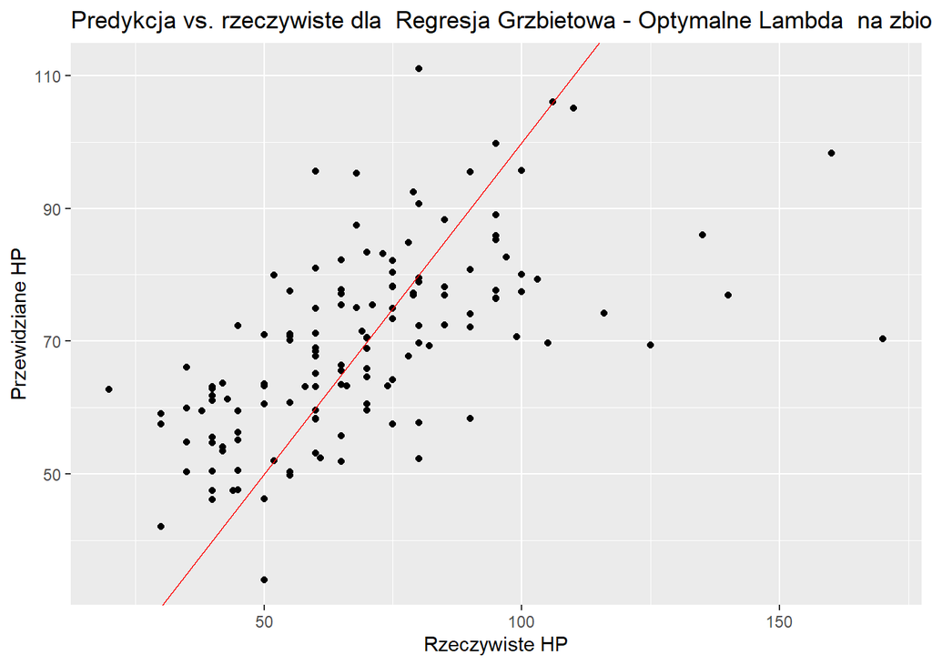

```r
output_best_ridge$prediction_plot
```

**Pokaż kod**

```r
output_larger_ridge$metrics_table
```

**Metryki modelu Regresja Grzbietowa - Większe Lambda**

| Metric | Value |
| --- | --- |
| MSE | 450.7848588 |
| RMSE | 21.2316947 |
| MAE | 15.0475150 |
| R-squared | 0.2777005 |

**Pokaż kod**

```r
output_larger_ridge$coefs_table
```

**Współczynniki modelu Regresja Grzbietowa - Większe Lambda**

| Variable | Coefficient |
| --- | --- |
| (Intercept) | 43.4202063 |
| attack | 0.0991670 |
| defense | 0.0322138 |
| sp_attack | 0.0781668 |
| sp_defense | 0.1246809 |
| speed | 0.0131263 |
| classBug | -5.0670310 |
| classElectric | -3.3089380 |
| classFire | -0.5171267 |
| classGrass | -0.2153849 |
| classNormal | 5.7175591 |
| classPsychic | 0.1075246 |
| classRock | -1.4327904 |
| classWater | 1.0801202 |

**Pokaż kod**

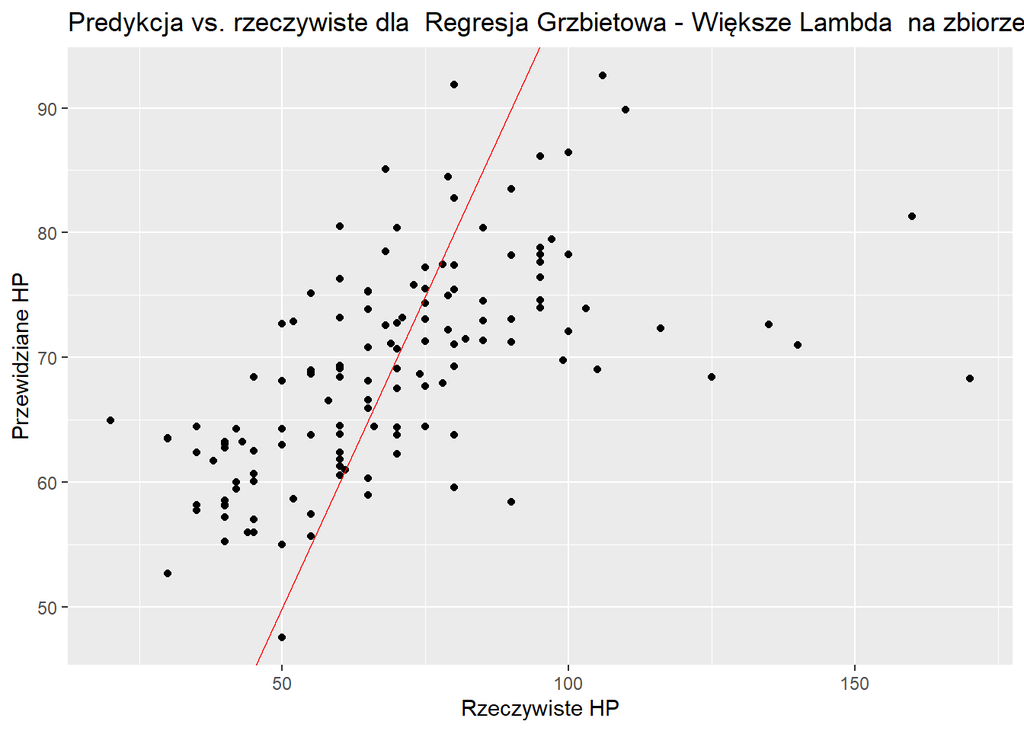

```r
output_larger_ridge$prediction_plot
```

## Porównanie metryk modeli w tabeli

**Pokaż kod**

```r
comparison_table_ridge <- data.frame(
    Model = c("Regresja Wieloraka", "Lasso - Optymalne Lambda", "Lasso - Większe Lambda", "Regresja Grzbietowa - Optymalne Lambda", "Regresja Grzbietowa - Większe Lambda"),
    MSE = c(mse_lm,
            mean((predict(lasso_model_best, s = best_lambda, newx = test_data) - test_labels)^2),
            mean((predict(lasso_model_larger, s = lambda_larger, newx = test_data) - test_labels)^2),
             mean((predict(ridge_model_best, s = best_lambda_ridge, newx = test_data) - test_labels)^2),
            mean((predict(ridge_model_larger, s = lambda_larger_ridge, newx = test_data) - test_labels)^2)),
    RMSE = c(rmse_lm,
            sqrt(mean((predict(lasso_model_best, s = best_lambda, newx = test_data) - test_labels)^2)),
            sqrt(mean((predict(lasso_model_larger, s = lambda_larger, newx = test_data) - test_labels)^2)),
             sqrt(mean((predict(ridge_model_best, s = best_lambda_ridge, newx = test_data) - test_labels)^2)),
            sqrt(mean((predict(ridge_model_larger, s = lambda_larger_ridge, newx = test_data) - test_labels)^2))),
    MAE = c(mae_lm,
            mean(abs(predict(lasso_model_best, s = best_lambda, newx = test_data) - test_labels)),
            mean(abs(predict(lasso_model_larger, s = lambda_larger, newx = test_data) - test_labels)),
             mean(abs(predict(ridge_model_best, s = best_lambda_ridge, newx = test_data) - test_labels)),
            mean(abs(predict(ridge_model_larger, s = lambda_larger_ridge, newx = test_data) - test_labels))),
    R_squared = c(r2_lm,
                1 - (sum((predict(lasso_model_best, s = best_lambda, newx = test_data) - test_labels)^2) / sum((test_labels - mean(test_labels))^2)),
             1 - (sum((predict(lasso_model_larger, s = lambda_larger, newx = test_data) - test_labels)^2) / sum((test_labels - mean(test_labels))^2)),
             1 - (sum((predict(ridge_model_best, s = best_lambda_ridge, newx = test_data) - test_labels)^2) / sum((test_labels - mean(test_labels))^2)),
             1 - (sum((predict(ridge_model_larger, s = lambda_larger_ridge, newx = test_data) - test_labels)^2) / sum((test_labels - mean(test_labels))^2)))
)


kbl(comparison_table_ridge, caption = "<center><strong>Porównanie metryk modeli na zbiorze testowym</strong></center>") |>
        kable_styling(bootstrap_options = c("striped", "hover"))
```

**Porównanie metryk modeli na zbiorze testowym**

| Model | MSE | RMSE | MAE | R_squared |
| --- | --- | --- | --- | --- |
| Regresja Wieloraka | 394.1834 | 19.85405 | 14.29713 | 0.3683939 |
| Lasso - Optymalne Lambda | 403.5354 | 20.08819 | 14.50557 | 0.3534091 |
| Lasso - Większe Lambda | 420.3971 | 20.50359 | 14.33871 | 0.3263913 |
| Regresja Grzbietowa - Optymalne Lambda | 403.1405 | 20.07836 | 14.42975 | 0.3540418 |
| Regresja Grzbietowa - Większe Lambda | 450.7849 | 21.23169 | 15.04752 | 0.2777005 |

Tabela porównawcza prezentuje metryki (MSE, RMSE, MAE, R-kwadrat) modeli regresji wielorakiej, Lasso (z optymalnym i większym lambda) oraz regresji grzbietowej (z optymalnym i większym lambda), obliczone na zbiorze testowym.

Model regresji wielorakiej nadal osiąga najlepsze wyniki w kategorii MSE, RMSE i MAE (MSE: 394.18, RMSE: 19.85, MAE: 14.29) i R-kwadrat (0.368). Model Lasso z optymalnym lambda jest nieco gorszy (MSE: 403.53, RMSE: 20.09, MAE: 14.51, R-squared 0.353) ale wciąż zbliżony do regresji wielorakiej.

Modele regresji grzbietowej (optymalny i większe lambda) wykazują gorsze dopasowanie niż model regresji wielorakiej, a regresja grzbietowa z większym lambda osiąga najgorszy wynik R-squared ze wszystkich modeli (0.278).

# Elastic Net

## Budowa modeli Elastic Net

**Pokaż kod**

```r
elastic_net_models <- list()

for (alpha in alpha_seq){
  cv_model_elastic <- cv.glmnet(train_data, train_labels, alpha = alpha, lambda = lambda_seq, nfolds = 10)
  best_lambda_elastic <- cv_model_elastic$lambda.min
  elastic_net_model <- glmnet(train_data, train_labels, alpha = alpha, lambda = best_lambda_elastic)
  model_name <- paste0("Elastic Net - alpha=", round(alpha, 2))
   elastic_net_models[[model_name]] <- list(model= elastic_net_model, lambda=best_lambda_elastic, alpha = alpha) # zapisanie modelu, lamdby i alpha
    print(paste("Najlepsza wartość lambda dla Elastic Net (alpha = ", round(alpha, 2), ") :", best_lambda_elastic))
}
```

```
[1] "Najlepsza wartość lambda dla Elastic Net (alpha =  0.1 ) : 0.794328234724281"
[1] "Najlepsza wartość lambda dla Elastic Net (alpha =  0.3 ) : 0.316227766016838"
[1] "Najlepsza wartość lambda dla Elastic Net (alpha =  0.5 ) : 0.251188643150958"
[1] "Najlepsza wartość lambda dla Elastic Net (alpha =  0.7 ) : 0.251188643150958"
[1] "Najlepsza wartość lambda dla Elastic Net (alpha =  0.9 ) : 0.199526231496888"
```

## Ocena modeli

**Pokaż kod**

```r
output_elastic_net <- list()
for(model_name in names(elastic_net_models)){
   output_elastic_net[[model_name]] <- evaluate_model(elastic_net_models[[model_name]]$model, elastic_net_models[[model_name]]$lambda, test_data, test_labels, model_name)

output_elastic_net[[model_name]]$metrics_table
output_elastic_net[[model_name]]$coefs_table
output_elastic_net[[model_name]]$prediction_plot
}
```

[output not shown]

## Porównanie modeli

**Pokaż kod**

```r
comparison_table_elastic <- data.frame(
  Model = c("Regresja Wieloraka", "Lasso - Optymalne Lambda = 0,158", "Lasso - Większe Lambda = 1,584",
             "Regresja Grzbietowa - Optymalne Lambda = 3.162", "Regresja Grzbietowa - Większe Lambda = 31,623"),
    MSE = c(mse_lm,
            mean((predict(lasso_model_best, s = best_lambda, newx = test_data) - test_labels)^2),
            mean((predict(lasso_model_larger, s = lambda_larger, newx = test_data) - test_labels)^2),
             mean((predict(ridge_model_best, s = best_lambda_ridge, newx = test_data) - test_labels)^2),
            mean((predict(ridge_model_larger, s = lambda_larger_ridge, newx = test_data) - test_labels)^2)),
    RMSE = c(rmse_lm,
            sqrt(mean((predict(lasso_model_best, s = best_lambda, newx = test_data) - test_labels)^2)),
            sqrt(mean((predict(lasso_model_larger, s = lambda_larger, newx = test_data) - test_labels)^2)),
             sqrt(mean((predict(ridge_model_best, s = best_lambda_ridge, newx = test_data) - test_labels)^2)),
            sqrt(mean((predict(ridge_model_larger, s = lambda_larger_ridge, newx = test_data) - test_labels)^2))),
    MAE = c(mae_lm,
            mean(abs(predict(lasso_model_best, s = best_lambda, newx = test_data) - test_labels)),
            mean(abs(predict(lasso_model_larger, s = lambda_larger, newx = test_data) - test_labels)),
           mean(abs(predict(ridge_model_best, s = best_lambda_ridge, newx = test_data) - test_labels)),
            mean(abs(predict(ridge_model_larger, s = lambda_larger_ridge, newx = test_data) - test_labels))),
   R_squared = c(r2_lm,
                1 - (sum((predict(lasso_model_best, s = best_lambda, newx = test_data) - test_labels)^2) / sum((test_labels - mean(test_labels))^2)),
             1 - (sum((predict(lasso_model_larger, s = lambda_larger, newx = test_data) - test_labels)^2) / sum((test_labels - mean(test_labels))^2)),
             1 - (sum((predict(ridge_model_best, s = best_lambda_ridge, newx = test_data) - test_labels)^2) / sum((test_labels - mean(test_labels))^2)),
             1 - (sum((predict(ridge_model_larger, s = lambda_larger_ridge, newx = test_data) - test_labels)^2) / sum((test_labels - mean(test_labels))^2)))
)
for(model_name in names(elastic_net_models)){
      predictions_elastic <- predict(elastic_net_models[[model_name]]$model, s =elastic_net_models[[model_name]]$lambda ,newx = test_data)
       mse_elastic <- mean((predictions_elastic - test_labels)^2)
       rmse_elastic <- sqrt(mse_elastic)
       mae_elastic <- mean(abs(predictions_elastic - test_labels))
      r2_elastic <- 1 - (sum((predictions_elastic - test_labels)^2) / sum((test_labels - mean(test_labels))^2))
  comparison_table_elastic <- rbind(comparison_table_elastic,  data.frame(
        Model = model_name,
        MSE = mse_elastic,
       RMSE = rmse_elastic,
        MAE = mae_elastic,
      R_squared =  r2_elastic
    ))

}

kbl(comparison_table_elastic, caption = "<center><strong>Porównanie metryk modeli</strong></center>") |>
        kable_styling(bootstrap_options = c("striped", "hover"))
```

**Porównanie metryk modeli**

| Model | MSE | RMSE | MAE | R_squared |
| --- | --- | --- | --- | --- |
| Regresja Wieloraka | 394.1834 | 19.85405 | 14.29713 | 0.3683939 |
| Lasso - Optymalne Lambda = 0,158 | 403.5354 | 20.08819 | 14.50557 | 0.3534091 |
| Lasso - Większe Lambda = 1,584 | 420.3971 | 20.50359 | 14.33871 | 0.3263913 |
| Regresja Grzbietowa - Optymalne Lambda = 3.162 | 403.1405 | 20.07836 | 14.42975 | 0.3540418 |
| Regresja Grzbietowa - Większe Lambda = 31,623 | 450.7849 | 21.23169 | 15.04752 | 0.2777005 |
| Elastic Net - alpha=0.1 | 403.1219 | 20.07789 | 14.50112 | 0.3540717 |
| Elastic Net - alpha=0.3 | 403.6515 | 20.09108 | 14.52406 | 0.3532230 |
| Elastic Net - alpha=0.5 | 403.5757 | 20.08919 | 14.51444 | 0.3533445 |
| Elastic Net - alpha=0.7 | 403.3416 | 20.08337 | 14.49152 | 0.3537196 |
| Elastic Net - alpha=0.9 | 403.3897 | 20.08456 | 14.49320 | 0.3536424 |

Tabela porównawcza przedstawia metryki (MSE, RMSE, MAE, R-kwadrat) uzyskane dla wszystkich modeli (regresji wielorakiej, Lasso, grzbietowej i Elastic Net) na zbiorze testowym.

Model regresji wielorakiej nadal osiąga najlepsze wyniki w kategorii MSE, RMSE i MAE (MSE: 394.18, RMSE: 19.85, MAE: 14.29) i R-kwadrat (0.368).

Modele Lasso i grzbietowe z optymalnymi parametrami mają nieco gorsze wyniki (metriki mieszczą się między 400 i 405 dla MSE, 20 i 21 dla RMSE, a 14 i 15 dla MAE, R-squared około 0.35). Widoczne jest, że wzrost parametru lambda (dla Lasso i grzbietowej) powoduje spadek jakości dopasowania. Zauważmy, że wszystkie metody regularyzacyjne (Lasso, Ridge, Elastic Net) nie pobiły wyników modelu regresji wielorakiej.

[figure not shown]